# Analysis of Cervical Cancer Risk Factors

Mariana Canelas Pais

2024-03-05

# Introduction

Cervical cancer is one of the leading causes of cancer-related deaths among women worldwide. The early identification of associated risk factors can significantly contribute to the prevention and effective treatment of this disease. This report focuses on analyzing the dataset concerning cervical cancer risk factors made available by the UCI repository, collected at ‘Hospital Universitario de Caracas’ in Caracas, Venezuela. The dataset comprises demographic information, habits, and historic medical records of 858 patients. Some patients chose not to answer certain questions due to privacy concerns, leading to missing values in the dataset.

## Dataset Characteristics

The dataset is multivariate, covering the health and medicine domain, specifically aimed at classification tasks. It includes both integer and real feature types across various variables.

## Variables Description

The dataset contains the following variables, among others, providing a comprehensive overview of each patient’s demographic background, habits, and medical history:

# Methods

This analysis aims to accurately classify the presence of cervical cancer (`Dx:Cancer`), comparing the performance of single decision trees and random forests. The evaluation of derived models will follow a correct methodology, comparing different estimates of generalization error, such as holdout, cross-validation, and bootstrap methods.

## Imports and Data Preparation

To conduct this analysis, we will utilize the `rpart` and `caret` packages in R. These packages provide the necessary functions for creating decision trees, random forests, and managing the data preparation process.

```r
library(rpart)
library(rpart.plot)
library(caret)
library(ggplot2)
library(gridExtra)
library(ROSE)
library(randomForest)
```

## Reading the Dataset

The dataset is loaded from a CSV file into an R dataframe for manipulation and analysis.

```r
fp <- "assignment_01/cervical.csv"
ds <- read.csv(fp)
```

## Data Cleaning

To ensure the quality and usability of the data, we perform several cleaning steps. This includes replacing “?” with NA for missing values, converting certain columns to factors to reflect their categorical nature, and transforming other columns to numeric types to enable quantitative analysis.

### Handling Missing Values and Data Types

First, we replace any “?” values with NA across specified columns, acknowledging the presence of missing data in both categorical and numeric fields.

```r
# List of columns to convert to factors
col_to_factor <- c(
  "Smokes",
  "Hormonal.Contraceptives",
  "IUD",
  "STDs",
  "STDs.condylomatosis",
  "STDs.cervical.condylomatosis",
  "STDs.vaginal.condylomatosis",
  "STDs.vulvo.perineal.condylomatosis",
  "STDs.syphilis",
  "STDs.pelvic.inflammatory.disease",
  "STDs.genital.herpes",
  "STDs.molluscum.contagiosum",
  "STDs.AIDS",
  "STDs.HIV",
  "STDs.Hepatitis.B",
  "STDs.HPV",
  "Dx.Cancer",
  "Dx.CIN",
  "Dx.HPV",
  "Dx",
  "Hinselmann",
  "Schiller",
  "Citology",
  "Biopsy"
)

# List of columns to convert to numeric
col_to_numeric <- c(
  "Number.of.sexual.partners",
  "First.sexual.intercourse",
  "Num.of.pregnancies",
  "Smokes..years.",
  "Smokes..packs.year.",
  "Hormonal.Contraceptives..years.",
  "STDs..Number.of.diagnosis",
  "STDs..Time.since.first.diagnosis",
  "STDs..Time.since.last.diagnosis",
  "IUD..years.",
  "STDs..number."
)

# Replace "?" with NA and convert data types
ds[c(col_to_factor, col_to_numeric)] <- lapply(ds[c(col_to_factor, col_to_numeric)], function(x) {
  x[x == "?"] <- NA
  return(x)
})
```

## Converting Data Types

After handling missing values, we convert the specified columns to their appropriate data types: factors for categorical variables and numeric for continuous variables.

```r
# Converting columns to factors
ds[col_to_factor] <- lapply(ds[col_to_factor], factor)

# Converting columns to numeric
ds[col_to_numeric] <- lapply(ds[col_to_numeric], as.numeric)
```

## Renaming Columns

To improve readability and simplify future references to the dataset columns, we rename them using a more consistent naming convention.

```r
# Renaming the columns for better readability
names(ds) <- c("Age", "NumSexualPartners", "FirstSexualIntercoarse", "NumPregnancies", "Smokes", "SmokesYears", "SmokesPacksYear", "HormonalContraceptives", "HormonalContraceptivesYears", "IUD", "IUDYears", "STDs", "STDsNumber", "STDsCondylomatosis", "STDsCervicalCondylomatosis", "STDsVaginalCondylomatosis", "STDsVulvoPerinealCondylomatosis", "STDsSyphilis", "STDsPelvicInflammatoryDisease", "STDsGenitalHerpes", "STDsMolluscumContagiosum", "STDsAIDS", "STDsHIV", "STDsHepatitisB", "STDsHPV", "STDsNumDiagnosis", "STDsTimeSinceFirstDiagnosis", "STDsTimeSinceLastDiagnosis", "DxCancer", "DxCIN", "DxHPV", "Dx", "Hinselmann", "Schiller", "Citology", "Biopsy")
```

## Variable Exclusion

To ensure the integrity of our analysis and prevent data leakage, we will remove variables that could introduce bias because they represent outcomes of diagnostics or are directly related to the target variable ‘Dx.Cancer’.

```r
# Excluding target variables from the dataset
ds <- ds[ , !(names(ds) %in% c("DxCIN", "DxHPV", "Dx", "Hinselmann", "Schiller", "Citology", "Biopsy"))]
```

In refining our dataset for the current exercise, we also undertook further variable selectionto ensure our models rely on variables that provide meaningful, independent insights into the risk factors without being encumbered by redundant or potentially confusing information.

```r
# Removing other variables from the dataset
ds <- ds[ , !(names(ds) %in% c("SmokesYears", "SmokesPacksYear", "HormonalContraceptives", "IUD", "STDs", "STDsNumber"))]
```

# Results

In this analysis, we aimed to balance our dataset to address the significant class imbalance present and subsequently trained decision tree models using both Gini impurity and information gain as splitting criteria. Here we present the process and findings of our modeling efforts.

## Balancing the Dataset

First, we balanced the dataset using the ROSE package’s over-sampling method to provide an equal representation of classes. This was crucial for improving our models’ ability to learn from the minority class.

[output not shown]

## Creating a Holdout Validation Set

For the correct evaluation of our models, we will hold out a portion of the dataset as a validation set. This allows us to assess the model’s performance on unseen data, providing a more accurate estimate of its generalization error. We partition the balanced dataset into training and validation subsets, ensuring that both sets maintain a similar class distribution.

```r
# Create indices for a stratified training set, holding out 20% of the data for validation
training.index <- createDataPartition(ds_balanced$DxCancer, p=0.8, list=FALSE)

# Define the validation set
validation <- ds_balanced[-training.index, ]

# Define the training set
training <- ds_balanced[training.index, ]

# Check the distribution of the target variable in both sets to ensure stratification
cat("Training set distribution of DxCancer:\n")
```

```
## Training set distribution of DxCancer:
```

```r
table(training$DxCancer)
```

```
##
##   0   1
## 654 627
```

```r
cat("\nValidation set distribution of DxCancer:\n")
```

```
##
## Validation set distribution of DxCancer:
```

```r
table(validation$DxCancer)
```

```
##
##   0   1
## 163 156
```

## Model Training

### Decision Tree with Gini Impurity

We trained a decision tree model using Gini impurity as the criterion for making splits.

```r
tree.gini <- rpart(DxCancer ~ ., data = training, method = "class",
                   parms = list(split = "gini"),
                   control = rpart.control(cp = 0.001, minsplit = 1, maxdepth = 30))
```

### Decision Tree with Information Gain

Similarly, we trained another model using information gain (entropy) as the split criterion.

```r
tree.information <- rpart(DxCancer ~ ., data=training,
                          parms = list(split = "information"))
```

### Random Forest Model

Next, we trained a Random Forest model on the same training set.

```r
rf.model <- randomForest(DxCancer ~ ., data=training, method="class", ntree=500, mtry=2, importance=TRUE)
```

## Model Summaries

After fitting our decision tree models using the training data, we can summarize the results to understand the model’s complexity, variable importance, and the decision-making process. Below, we present the summaries for both models trained with Gini impurity and information gain as splitting criteria.

### Decision Tree Using Gini Impurity

```r
summary(tree.gini)
```

```
## Call:
## rpart(formula = DxCancer ~ ., data = training, method = "class",
##     parms = list(split = "gini"), control = rpart.control(cp = 0.001,
##         minsplit = 1, maxdepth = 30))
##   n= 1281
##
##            CP nsplit rel error   xerror       xstd
## 1 0.015629984      0 1.0000000 1.000000 0.02853517
## 2 0.010366826      5 0.9218501 1.068581 0.02851123
## 3 0.007974482      7 0.9011164 1.038278 0.02853768
## 4 0.005316321      8 0.8931419 1.035088 0.02853900
## 5 0.003189793     14 0.8564593 1.020734 0.02854151
## 6 0.001594896     15 0.8532695 1.023923 0.02854144
## 7 0.001196172     16 0.8516746 1.035088 0.02853900
## 8 0.001000000     20 0.8468900 1.036683 0.02853838
##
## Variable importance
##                         Age              NumPregnancies
##                          15                          15
##           NumSexualPartners                     STDsHPV
##                          12                          10
##      FirstSexualIntercoarse HormonalContraceptivesYears
##                          10                          10
##                    IUDYears STDsTimeSinceFirstDiagnosis
##                           7                           7
##  STDsTimeSinceLastDiagnosis                      Smokes
##                           6                           3
##            STDsNumDiagnosis              STDsHepatitisB
##                           1                           1
##                     STDsHIV                STDsSyphilis
##                           1                           1
##
## Node number 1: 1281 observations,    complexity param=0.01562998
##   predicted class=0  expected loss=0.4894614  P(node) =1
##     class counts:   654   627
##    probabilities: 0.511 0.489
##   left son=2 (12 obs) right son=3 (1269 obs)
##   Primary splits:
##       NumPregnancies                < 0.5   to the left,  improve=5.804109, (0 missing)
##       STDsPelvicInflammatoryDisease splits as  RL,        improve=5.804109, (0 missing)
```

[output cut: 381 more lines]

```
##
## Node number 14137: 25 observations
##   predicted class=1  expected loss=0.4  P(node) =0.019516
##     class counts:    10    15
##    probabilities: 0.400 0.600
##
## Node number 28272: 21 observations
##   predicted class=0  expected loss=0.4285714  P(node) =0.01639344
##     class counts:    12     9
##    probabilities: 0.571 0.429
##
## Node number 28273: 107 observations
##   predicted class=1  expected loss=0.4859813  P(node) =0.08352849
##     class counts:    52    55
##    probabilities: 0.486 0.514
```

The Gini model summary indicates the complexity parameter (CP) used at each split, the number of splits (nsplit), the relative error of the model, and the cross-validated relative error (xerror). The most important variables for splitting in the Gini model include Age, FirstSexualIntercoarse, NumPregnancies, and NumSexualPartners, among others. The model attempted several splits, optimizing the CP to reduce overfitting while attempting to capture the complexity of the data.

### Decision Tree Using Information Gain

```r
summary(tree.information)
```

```
## Call:
## rpart(formula = DxCancer ~ ., data = training, parms = list(split = "information"))
##   n= 1281
##
##           CP nsplit rel error   xerror       xstd
## 1 0.01562998      0 1.0000000 1.000000 0.02853517
## 2 0.01036683      5 0.9218501 1.028708 0.02854081
## 3 0.01000000      7 0.9011164 1.043062 0.02853517
##
## Variable importance
##              NumPregnancies                     STDsHPV
##                          26                          19
##                         Age                    IUDYears
##                          17                           8
## STDsTimeSinceFirstDiagnosis  STDsTimeSinceLastDiagnosis
##                           7                           7
## HormonalContraceptivesYears           NumSexualPartners
##                           6                           5
##      FirstSexualIntercoarse              STDsHepatitisB
##                           3                           1
##                      Smokes   STDsVaginalCondylomatosis
##                           1                           1
##
## Node number 1: 1281 observations,    complexity param=0.01562998
##   predicted class=0  expected loss=0.4894614  P(node) =1
##     class counts:   654   627
##    probabilities: 0.511 0.489
##   left son=2 (12 obs) right son=3 (1269 obs)
##   Primary splits:
##       NumPregnancies                < 0.5   to the left,  improve=8.121856, (0 missing)
##       STDsPelvicInflammatoryDisease splits as  RL,        improve=8.121856, (0 missing)
##       STDsHPV                       splits as  LR,        improve=6.463262, (0 missing)
##       IUDYears                      < 3.5   to the right, improve=2.654544, (0 missing)
##       FirstSexualIntercoarse        < 19.5  to the left,  improve=1.950426, (0 missing)
##
## Node number 2: 12 observations
##   predicted class=0  expected loss=0  P(node) =0.009367681
##     class counts:    12     0
##    probabilities: 1.000 0.000
##
```

[output cut: 106 more lines]

```
##       STDsTimeSinceLastDiagnosis < 5.5   to the left,  agree=1.000, adj=1.000, (0 split)
##       FirstSexualIntercoarse     < 13.5  to the right, agree=0.835, adj=0.398, (0 split)
##       NumPregnancies             < 3.5   to the left,  agree=0.798, adj=0.263, (0 split)
##       STDsHepatitisB             splits as  LR,        agree=0.793, adj=0.248, (0 split)
##       Age                        < 28.5  to the left,  agree=0.736, adj=0.038, (0 split)
##
## Node number 218: 351 observations
##   predicted class=0  expected loss=0.4558405  P(node) =0.2740047
##     class counts:   191   160
##    probabilities: 0.544 0.456
##
## Node number 219: 133 observations
##   predicted class=1  expected loss=0.4511278  P(node) =0.1038251
##     class counts:    60    73
##    probabilities: 0.451 0.549
```

The summary of the tree trained using information gain shows a similar structure, with the model highlighting the variable importance based on the information gain criterion. Variables like NumPregnancies, STDsHPV, Age, and IUDYears played significant roles in the model’s decision-making process. This model also details the nodes, splits, and the primary and surrogate splits at each node, demonstrating how the model decides the predicted class.

### Random Forest Model Summary

The following code obtains a summary pertraining the Random Forest model.

```r
summary(rf.model)
```

```
##                 Length Class  Mode
## call               7   -none- call
## type               1   -none- character
## predicted       1281   factor numeric
## err.rate        1500   -none- numeric
## confusion          6   -none- numeric
## votes           2562   matrix numeric
## oob.times       1281   -none- numeric
## classes            2   -none- character
## importance        88   -none- numeric
## importanceSD      66   -none- numeric
## localImportance    0   -none- NULL
## proximity          0   -none- NULL
## ntree              1   -none- numeric
## mtry               1   -none- numeric
## forest            14   -none- list
## y               1281   factor numeric
## test               0   -none- NULL
## inbag              0   -none- NULL
## terms              3   terms  call
```

The summary of the Random Forest model provides a comprehensive overview of the model’s training process and its outcomes. Notably, the model was trained with a large number of decision trees (ntree), which collectively contribute to the final prediction through a majority vote mechanism.

## Visualization of Decision Trees

Next, we visualize the structure of the trained decision trees to interpret the splits and leaf nodes.

### Decision Tree Using Gini Impurity

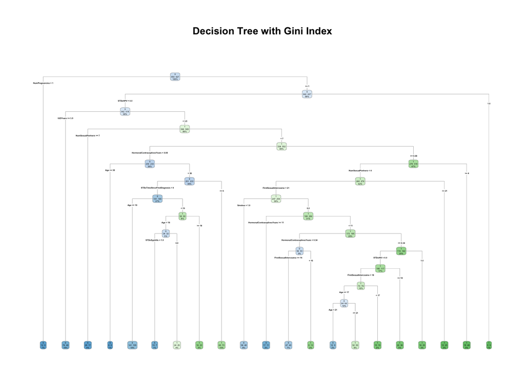

```r
rpart.plot(tree.gini, main = "Decision Tree with Gini Index", type = 4, extra = 101)
```

### Decision Tree Using Information Gain

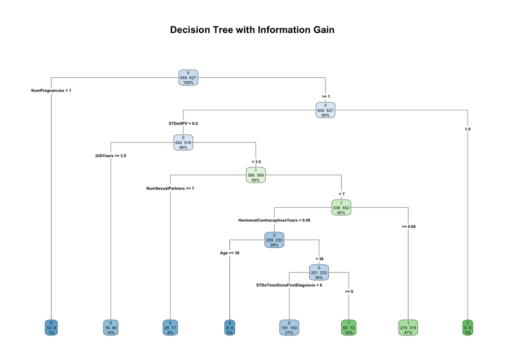

```r
rpart.plot(tree.information, main = "Decision Tree with Information Gain", type = 4, extra = 101)
```